# Generalized Linear Models

Peter Ralph

1 December 2020 – Advanced Biological Statistics

# Notation note

## Matrix multiplication

If

- $b$ is a $k$-vector
- $X$ is an $n \times k$ matrix

then “$X b$” is shorthand for the $n$-vector
$$(Xb)_i = \sum_{j=1}^k X_{ij} b_j .$$

- In R, we use `%*%`.
- In Stan, we use `*`.

## Example

Let’s say we want to predict apple `yield` using `leaf_area`, `tree_age`, and `fertilizer`:
$$\begin{aligned}
\text{yield}_i &= \beta_0 + \beta_1 \times \text{leaf_area}_i \\
&\qquad {} + \beta_2 \times \text{tree_age}_i
+ \beta_3 \times \text{fertilizer}_i + \epsilon_i.
\end{aligned}$$

If we set the columns of $X$ to be

1. all 1s
2. `leaf_area`
3. `tree_age`
4. `fertilizer`

and $\beta = (\beta_0, \beta_1, \beta_2, \beta_3),$ then this is
$$\text{yield}_i = (X \beta)_i + \epsilon_i .$$

Or,
$$\text{yield} = X \beta + \epsilon .$$

The `model.matrix( )` function gives you back an `X` matrix appropriate for *factors* as well.

# Generalized Linear Models

## Ingredients of a GLM:

1. A probability distribution, $Y$.

> *(the “family”; describes the output)*
2. A linear predictor, $X \beta$.

> *(connects input to output)*
3. A link function (usually, $h(\E[Y]) = X\beta$).

> *(connects linear predictor to probability distribution)*

## Common choices:

- Linear:
  $$Y \sim \Normal(X \beta, \sigma) .$$
- Binomial (“Logistic”):
  $$Y \sim \Binom(n, \logistic(X\beta)) .$$
- Poisson:
  $$Y \sim \Poisson(\exp(X\beta)) .$$
- Gamma:
  $$Y \sim \Gam(\text{scale}=\exp(X\beta)/k, \text{shape}=k) .$$

## Logistic GLM, in R

```
glm(y ~ x, family=binomial)
```

```
family {stats}

Family objects provide a convenient way to specify the details of the models
used by functions such as glm.

binomial(link = "logit")
gaussian(link = "identity")
Gamma(link = "inverse")
inverse.gaussian(link = "1/mu^2")
poisson(link = "log")

Arguments

link: a specification for the model link function. This can be a
name/expression, a literal character string, a length-one character vector, or
an object of class "link-glm" (such as generated by make.link) provided it is
not specified via one of the standard names given next.

The gaussian family accepts the links (as names) identity, log and inverse; the
binomial family the links logit, probit, cauchit, (corresponding to logistic,
normal and Cauchy CDFs respectively) log and cloglog (complementary log-log);
the Gamma family the links inverse, identity and log; the poisson family the
links log, identity, and sqrt; and the inverse.gaussian family the links
1/mu^2, inverse, identity and log.
```

Note that the link function is the *inverse* of what we’d write down in the model: for instance, if the mean of the response is the exponential of the linear predictor, i.e., if
$$\E[Y] = \exp(X\beta) .$$
then we have

```
link = "log"
```

Other inverses:

- `logistic` has inverse `logit`
- `identity` has inverse `identity`
- `x^2` (“squared”) has inverse `sqrt`

# Unpacking the logistic GLM

## Simulate data

100 trials, where probability of success depends on $x$:

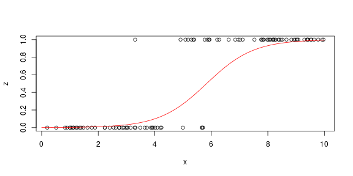

```r
alpha <- -7; beta <- 1.2
x <- runif(100, 0, 10)
y <- alpha + beta * x
p <- 1 / (1 + exp(-y))
z <- rbinom(100, size=1, prob=p)
plot(z ~ x)
curve(1/(1+exp(-(-7 + 1.2 *x))), 0, 10, col='red', add=TRUE)
```

## `glm()`

```r
zz <- cbind(z, 1-z)
summary(glm_fit <- glm(zz ~ x, family='binomial'))
```

```
##
## Call:
## glm(formula = zz ~ x, family = "binomial")
##
## Deviance Residuals:
##      Min        1Q    Median        3Q       Max
## -1.79584  -0.14355   0.01418   0.07181   2.58115
##
## Coefficients:
##             Estimate Std. Error z value Pr(>|z|)
## (Intercept)  -9.7512     2.4701  -3.948 7.89e-05 ***
## x             1.9531     0.4849   4.028 5.62e-05 ***
## ---
## Signif. codes:  0 '***' 0.001 '**' 0.01 '*' 0.05 '.' 0.1 ' ' 1
##
## (Dispersion parameter for binomial family taken to be 1)
##
##     Null deviance: 138.269  on 99  degrees of freedom
## Residual deviance:  28.807  on 98  degrees of freedom
## AIC: 32.807
##
## Number of Fisher Scoring iterations: 7
```

## Stan

$$\begin{aligned}
Z &\sim \Binom(1, P) \\
P &= \logistic(\alpha + \beta X)
\end{aligned}$$

```r
logistic_block <- "
data {
    int N;
    vector[N] X;
    int<lower=0> Z[N];
}
parameters {
    real alpha;
    real beta;
}
model {
    vector[N] p;
    p = inv_logit(alpha + beta * X);
    Z ~ binomial(1, p);
}"
```

## Stan: fit the model

```r
logistic_model <- stan_model(model_code=logistic_block)
fit <- sampling(logistic_model, chains=3, iter=1000,
            data=list(N=100, X=x, Z=z))
rstan::summary(fit)$summary
```

```
##             mean    se_mean       sd       2.5%        25%        50%        75%      97.5%    n_eff     Rhat
## alpha -11.231396 0.19863109 2.917856 -18.153892 -12.818953 -10.877573  -9.235022  -6.703278 215.7910 1.017132
## beta    2.245831 0.03897684 0.568362   1.364083   1.848582   2.187879   2.551442   3.576015 212.6360 1.017964
## lp__  -15.467009 0.06580101 1.124115 -18.564140 -15.838721 -15.127840 -14.697168 -14.435249 291.8477 1.007922
```

## Stan: posterior distributions

[figure not shown]

```r
samples <- extract(fit)
layout(t(1:2))
hist(samples$alpha, main=expression(alpha))
abline(v=alpha, col='red'); abline(v=coef(glm_fit)[1], col='green')
hist(samples$beta, main=expression(beta))
abline(v=beta, col='red'); abline(v=coef(glm_fit)[2], col='green')
legend("topright", lty=1, col=c('red', 'green'), legend=c('truth', 'glm'))
```

# Identify the GLM

```
data {
  int N;
  vector[N] X;
  vector[N] Y;
  vector<lower=0> Z[N];
}
parameters {
  real beta[2];
}
model {
  Z ~ gamma(1, exp(- beta[1] * X - beta[2] * Y));
}
```

What is

1. the probability distribution? *(describes the output)*
2. the linear predictor? *(connects input to output)*
3. the link function? *(connects linear predictor to probability distribution)*

**Then,** simulate from it.